# Analysis of the number of people living in a household

Group_01

# project2_test

Group_01

2021/7/7

## Introduction

We have a survey from the Philippines. This survey is conducted every three years to provide data on household income and expenditures. Our dataset is from one of the Philippine regions.The purpose of this article is to know which variables related to households affect the number of people living in a household? Therefore, we will analyze 1725 observations.

## Exploratory Data Analysis

We will explore whether nine variables related to households in the dataset have an impact on the number of people living in the house (Total.Number.of.Family.members). These nine variables are Annual household income, Annual expenditure by the household on food, Head of the households sex, Head of the households age, Relationship between the group of people living in the house, Floor area of the house, Age of the building, Number of bedrooms in the house and House electrification situation.

First let’s look at the scatterplot of the response variable versus the numerical variable.

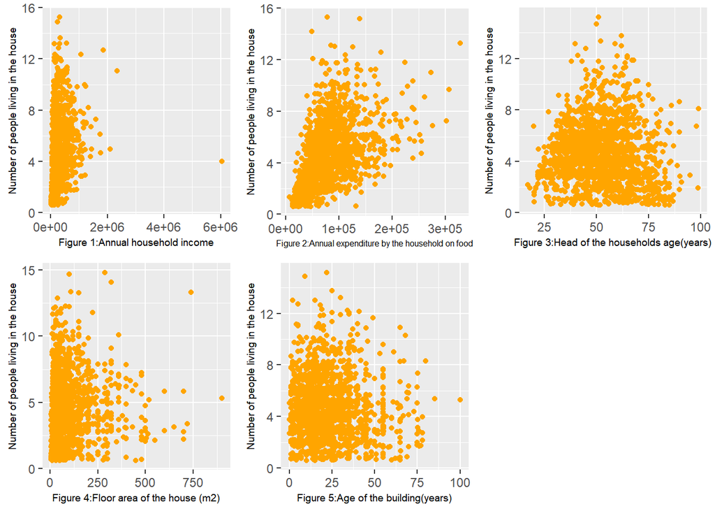

# Introduction

Data come from the FIES (Family Income and Expenditure Survey) recorded in the Philippines. The survey, which is undertaken every three years, is aimed at providing data on family income and expenditure. The data obtained from this survey are from different regions across the Philippines. This report will focus on one individual area, the Cordillera Administrative Region and so region has been removed from the dataset as it will not be informative as an explanatory variable.

The report will investigate which household related variables influence the number of people living in a household. The data used consists of 1725 observations of ten variables, two of which are categorical and the remaining are numerical.

The distribution of the response variable of the number of members in a household can be seen in the Figure 1. The modal response is 4 members and the distribution is right-skewed.

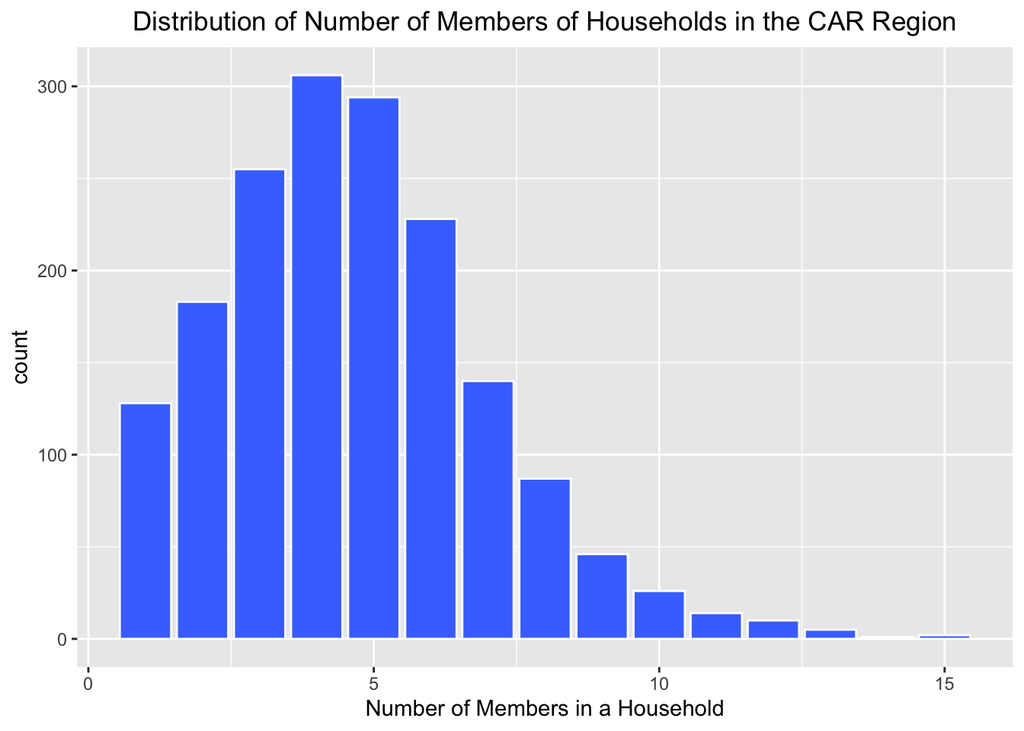

Distribution of Response Variable

The summary below shows the count data for each level of the response variable and the percentage of total households in the region in each group.

```
 Total.Number.of.Family.members    n percent
                              1  128    7.4%
                              2  183   10.6%
                              3  255   14.8%
                              4  306   17.7%
                              5  294   17.0%
                              6  228   13.2%
                              7  140    8.1%
                              8   87    5.0%
                              9   46    2.7%
                             10   26    1.5%
                             11   14    0.8%
                             12   10    0.6%
                             13    5    0.3%
                             14    1    0.1%
                             15    2    0.1%
                          Total 1725  100.0%
```

There is a moderate positive correlation (0.611) between the total household income and the household food expenditure. Additionally there is a slight positive correlation between the total household income and the number of bedrooms in the household (0.441) and the number of family members and total food expenditure (0.469. The other variables are all weakly correlated.

```
                               Total.Number.of.Family.members
Total.Number.of.Family.members                     1.00000000
Total.Household.Income                             0.19228742
Total.Food.Expenditure                             0.46924215
Household.Head.Age                                -0.06541636
House.Floor.Area                                  -0.01415702
House.Age                                         -0.07003586
Number.of.bedrooms                                 0.07207630
Electricity                                        0.09193871
                               Total.Household.Income Total.Food.Expenditure
Total.Number.of.Family.members             0.19228742            0.469242145
Total.Household.Income                     1.00000000            0.611494530
Total.Food.Expenditure                     0.61149453            1.000000000
Household.Head.Age                         0.06280405           -0.051724735
House.Floor.Area                           0.23413840            0.124320633
House.Age                                  0.02471720            0.006725185
Number.of.bedrooms                         0.44137375            0.355734454
Electricity                                0.14866655            0.198610366
                               Household.Head.Age House.Floor.Area    House.Age
Total.Number.of.Family.members        -0.06541636      -0.01415702 -0.070035856
Total.Household.Income                 0.06280405       0.23413840  0.024717197
Total.Food.Expenditure                -0.05172474       0.12432063  0.006725185
Household.Head.Age                     1.00000000       0.09057216  0.218079293
House.Floor.Area                       0.09057216       1.00000000  0.074265080
House.Age                              0.21807929       0.07426508  1.000000000
Number.of.bedrooms                     0.15415511       0.37399081  0.123180471
Electricity                           -0.01304412       0.10693465  0.085327324
                               Number.of.bedrooms Electricity
Total.Number.of.Family.members          0.0720763  0.09193871
Total.Household.Income                  0.4413738  0.14866655
Total.Food.Expenditure                  0.3557345  0.19861037
Household.Head.Age                      0.1541551 -0.01304412
House.Floor.Area                        0.3739908  0.10693465
House.Age                               0.1231805  0.08532732
Number.of.bedrooms                      1.0000000  0.21376315
Electricity                             0.2137632  1.00000000
```

The pairs plot in Figure 2 is colour coded to illustrate any differences between the distributions of the quantitative variables when the head of household sex is included as a factor. The plots suggest the sex of the head of household may impact the number of family members in the household and the age of the head of the household.

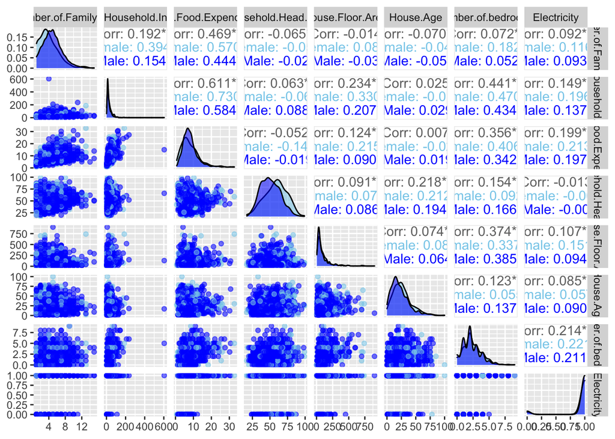

Pair plots and correlation between numerical variables, colour coded to show the sex of the head of household.

Table 1 shows the summaries for each of the numerical variables. There is no missing data within these variables and so no values will need to be imputed for the analysis in the report. There appear to be possible outliers at the maximum values of Total Household Income and House Floor Area.

Summary statistics of numerical variables.

| Variable | Missing | Complete | Mean | SD | Min. | 1st Q. | Median | 3rd Q. | Max. |
| --- | --- | --- | --- | --- | --- | --- | --- | --- | --- |
| Total.Number.of.Family.members | 0 | 1 | 4.67 | 2.33 | 1.00 | 3.00 | 4.00 | 6.00 | 15.00 |
| Total.Household.Income | 0 | 1 | 26.95 | 27.46 | 1.20 | 11.86 | 18.86 | 32.83 | 604.29 |
| Total.Food.Expenditure | 0 | 1 | 8.04 | 4.12 | 0.68 | 5.19 | 7.36 | 9.85 | 32.77 |
| Household.Head.Age | 0 | 1 | 52.23 | 14.52 | 17.00 | 41.00 | 52.00 | 63.00 | 99.00 |
| House.Floor.Area | 0 | 1 | 90.92 | 99.20 | 5.00 | 32.00 | 54.00 | 102.00 | 900.00 |
| House.Age | 0 | 1 | 22.98 | 15.32 | 0.00 | 12.00 | 20.00 | 31.00 | 100.00 |
| Number.of.bedrooms | 0 | 1 | 2.26 | 1.44 | 0.00 | 1.00 | 2.00 | 3.00 | 9.00 |
| Electricity | 0 | 1 | 0.93 | 0.26 | 0.00 | 1.00 | 1.00 | 1.00 | 1.00 |

The two tables above show the summaries of the two categorical variables. Single family households make up approximately two-thirds of the survey responses in this region and only 0.5% (8) of responses came from households formed from non-related individuals. Of the 1725 households, less than a quarter (21.4%) had a female head of household.

| Household.Head.Sex | n | percent |
| --- | --- | --- |
| Female | 369 | 21.4% |
| Male | 1356 | 78.6% |
| Total | 1725 | 100.0% |

| Type.of.Household | n | percent |
| --- | --- | --- |
| Extended Family | 569 | 33.0% |
| Single Family | 1148 | 66.6% |
| Two or More Nonrelated Persons/Members | 8 | 0.5% |
| Total | 1725 | 100.0% |

Figure 3 shows that an extended family household or one formed by non-related individuals is more likely to have a female head, whereas a larger proportion of single family households have male heads.

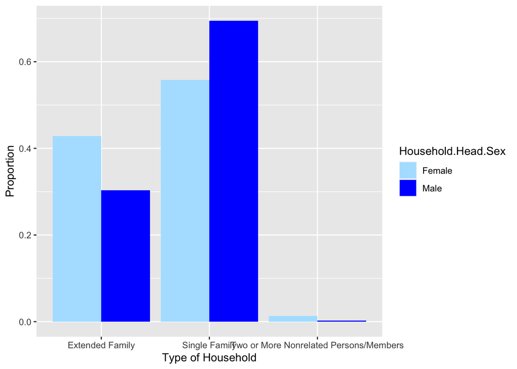

Barplot of household head’s sex by type of household

## Analysis of Relationships between Explanatory Variables

### Gender & Age

As highlighted by the pairs plot, there appears to be a relationship between the sex and age of the head of the household.

The minimum and maximum ages of household heads do not appear to differ greatly according to the individuals’ sex, however they do differ at the 25th, 50th and 75th percentiles with male heads of households being consitently younger than their female counterparts. The standard deviation is also greater for the female group, but the substantially smaller group size for females may contribute to this larger variation.

Summary statistics on the age of household heads by sex.

| Household.Head.Sex | n | Mean | St.Dev | Min | Q1 | Median | Q3 | Max |
| --- | --- | --- | --- | --- | --- | --- | --- | --- |
| Female | 369 | 58.23 | 15.69 | 17 | 47 | 59 | 69 | 99 |
| Male | 1356 | 50.59 | 13.74 | 20 | 40 | 49 | 61 | 98 |

The boxplot in Figure 4 illustrates the previously summarised data. The boxplot identifies the two oldest male head of households as outliers (shown by the points above the whisker), however within the context of the data and when compared to the ages of female head of household boxplot, these ages do not appear unreasonable or unrealistic.

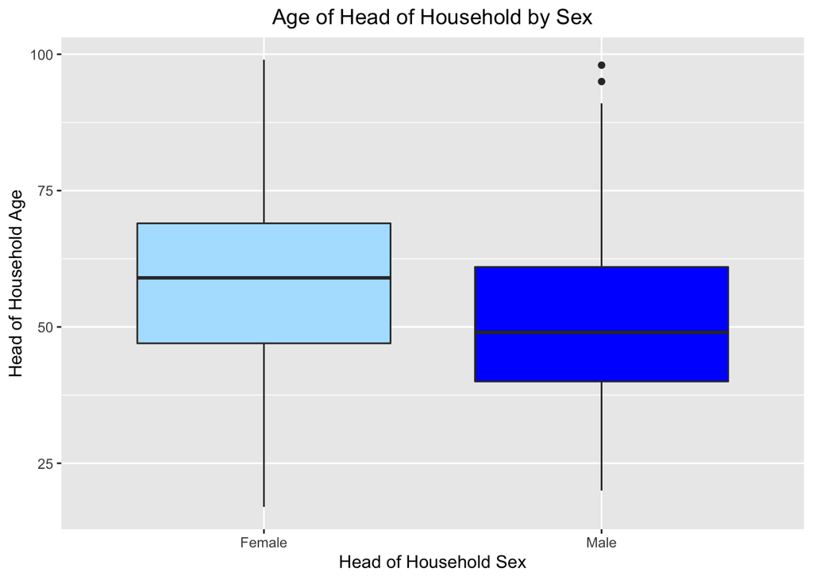

Boxplots of Head of Household Age stratified by Sex

The following Mann-Whitney U-test shows that there is a statistically significant difference in the median ages of male and female head of households at a 5% level.

```
    Wilcoxon rank sum test with continuity correction

data:  data.gender$Household.Head.Age by data.gender$Household.Head.Sex
W = 324284, p-value < 2.2e-16
alternative hypothesis: true location shift is not equal to 0
```

### Household Income Balance

Figure 5 shows a boxplot of household incomes suggests a heavily skewed distribution with many outliers at the upper end of the distribution.

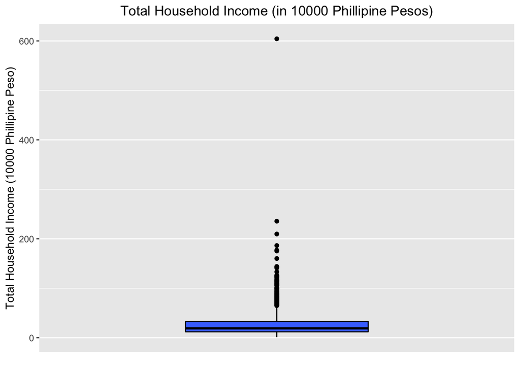

Household Incomes in 10000 Phillipine Pesos.

The following boxplot in Figure 6 shows the log transformed household income and shows there are still several outliers following the transformation.

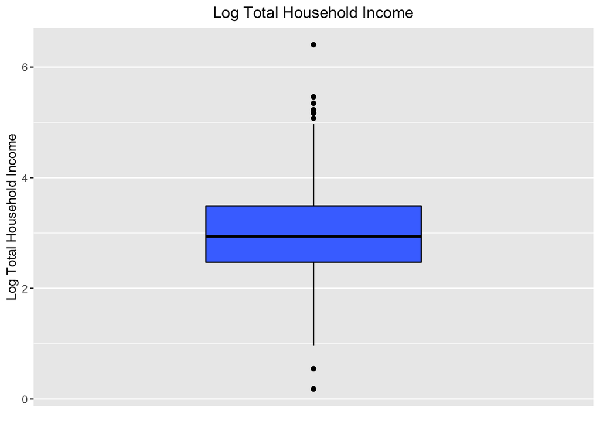

Boxplot of log transformed Incomes.

The scatterplot in Figure 7 of household income against total food expenditure suggests a positive correlation but the fitted model may be being heavily influenced by the extreme values, particularly by one extreme point.

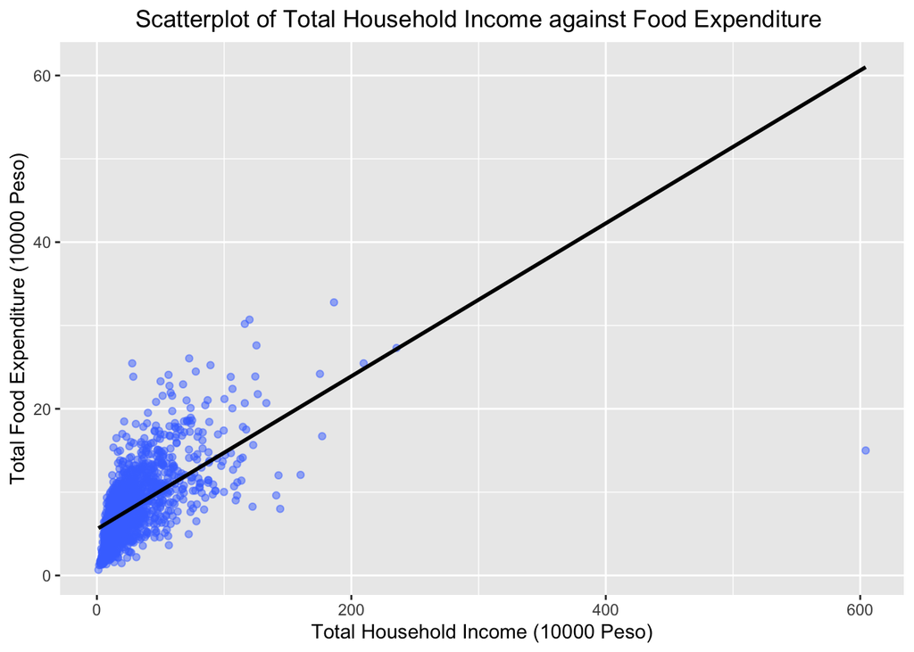

Scatterplot of Income against Food Expenditure.

Figure 7 again highlights a possible outlier in terms of income, this could be a data entry error or just an outlier at the maximum. Removing this observation from the data set and plotting provides the following scatter diagram in Figure 8. This plot reconfirms the suggested positive correlation, but there is still an imbalance in the amount of data available at different levels of income. For example, most data is available for incomes between 0 and 750000 peso, but far fewer data points occur above this income level.

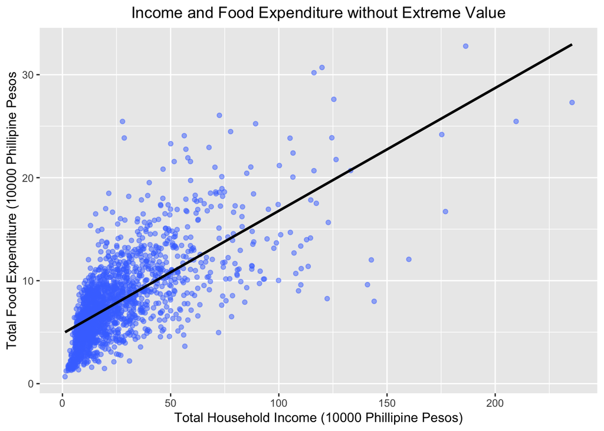

Scatterplot of Income and Food Expenditure with extreme value removed.

### Family Members & Head of Household Sex

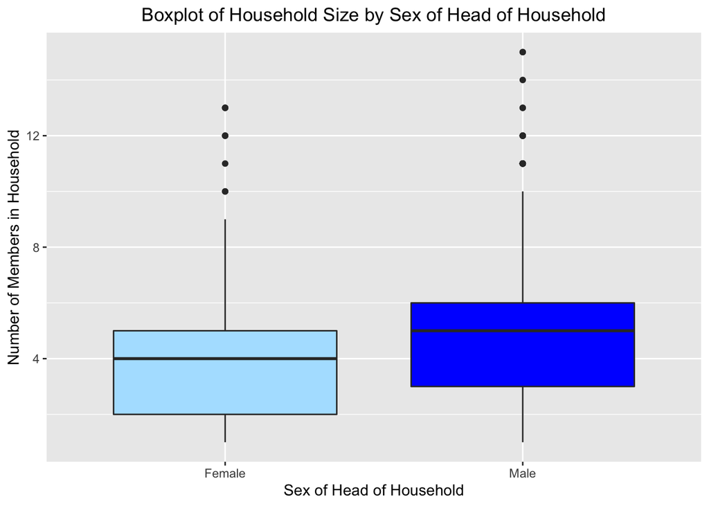

Number of Members in Household by Sex of Head of Household

Hence we can see from Figure 9 that households with a male head appear to have a greater number of family members on average than those with a female head, as the male group has larger values for the first and third quartiles and the median. However there is overlap between the two groups central IQR and so the distributions may not be significantly different.

#### Log-odds

```
Call:
glm(formula = Household.Head.Sex ~ Total.Number.of.Family.members,
    family = binomial(link = "logit"), data = data.sex_number)

Deviance Residuals:
    Min       1Q   Median       3Q      Max
-2.4219   0.4705   0.6602   0.7163   0.9054

Coefficients:
                               Estimate Std. Error z value Pr(>|z|)
(Intercept)                     0.49674    0.13174   3.771 0.000163 ***
Total.Number.of.Family.members  0.18319    0.02844   6.442 1.18e-10 ***
---
Signif. codes:  0 '***' 0.001 '**' 0.01 '*' 0.05 '.' 0.1 ' ' 1

(Dispersion parameter for binomial family taken to be 1)

    Null deviance: 1790.9  on 1724  degrees of freedom
Residual deviance: 1745.4  on 1723  degrees of freedom
AIC: 1749.4

Number of Fisher Scoring iterations: 4
```

$$\begin{align} \ln\left(\frac{p}{1-p}\right) &= \alpha + \beta \cdot \textrm{number of family members} = 0.5 + 0.18 \cdot
\textrm{number of family members}, \nonumber \end{align}$$

Where $p = Prob(Male)$ and $1-p = Prob(Female)$.

However, we are also interested in producing a 95% confidence interval for these log-odds.

95% Confidence Interval for log-odds

|  | 2.5 % | 97.5 % |
| --- | --- | --- |
| (Intercept) | 0.238899 | 0.755535 |
| Total.Number.of.Family.members | 0.128235 | 0.239747 |

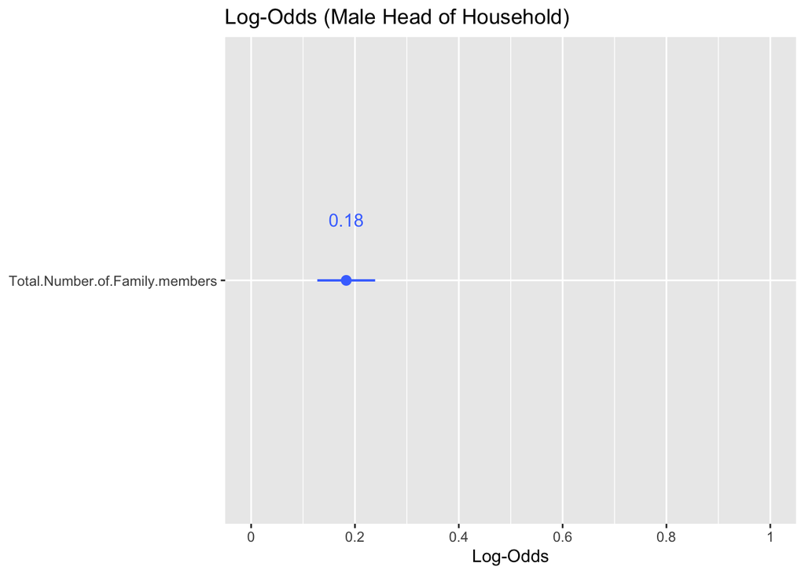

Log odds of a Male Head of Household

Now, let’s add the estimates of the log-odds to our data set:

#### Odds

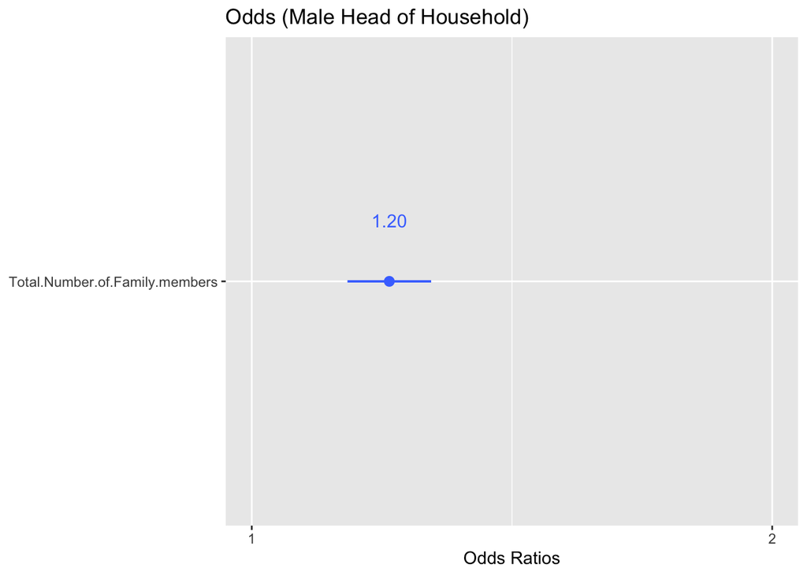

Odds of a Male Head of Household

Now, let’s add the estimates of the odds to our data set:

#### Probabilities

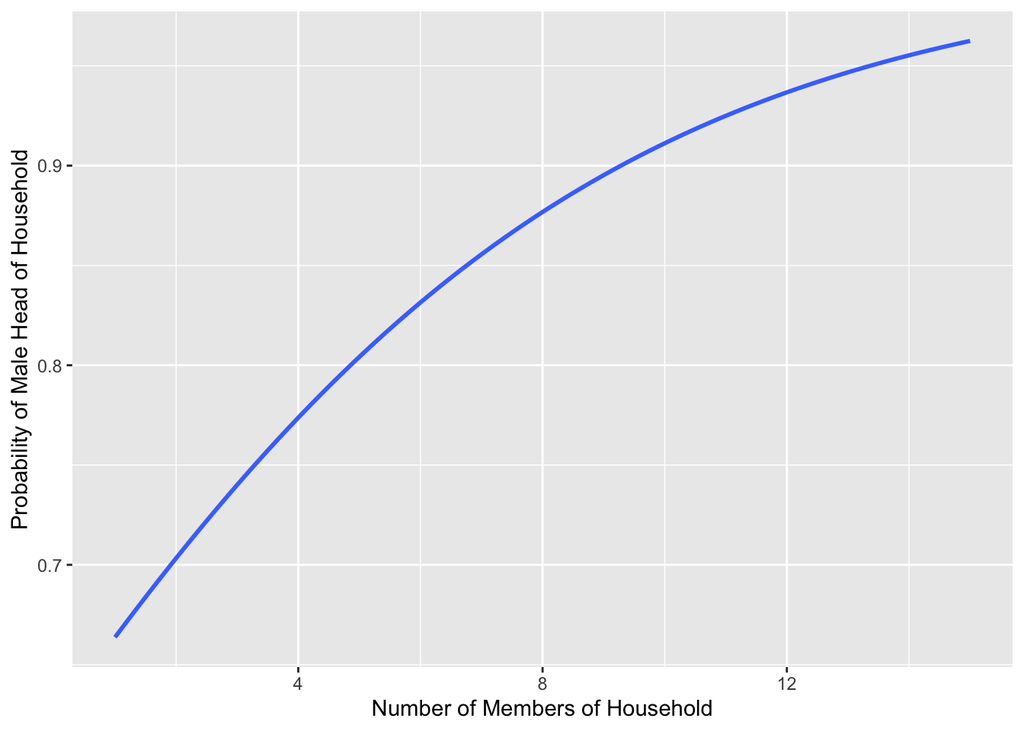

Probability of Male Head of Household given Number of Household Members

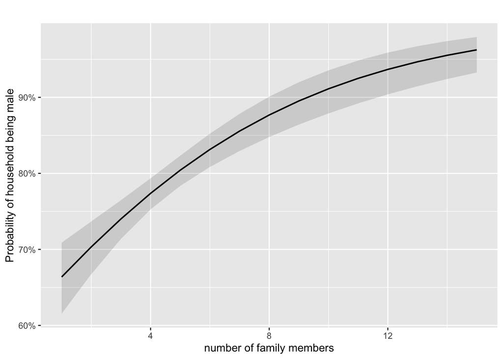

Predicted probability of Male Head of Households given Number of Household Members

## Model Exploration

Prior to exploring any models, the outlier for Total Household Income and corresponding measurements for the other variables from this individual are removed.

The following code identifies which explanatory variables would be included to produce the best models of different sizes, in this instance the maximum number of variables specified is ten. The output suggests the first predictor to be included is the total food expenditure in 10000 Phillipine pesos, and the last to be included is the binary variable Electricity that identifies if a household has electricity. Comparing each of the ten models produced by BIC, CP and adjusted R^2 criteria is inconclusive as each implies a different model is best.

```
Subset selection object
Call: regsubsets.formula(Total.Number.of.Family.members ~ ., data = data,
    nvmax = 10)
10 Variables  (and intercept)
                                                        Forced in Forced out
Total.Household.Income                                      FALSE      FALSE
Total.Food.Expenditure                                      FALSE      FALSE
Household.Head.SexMale                                      FALSE      FALSE
Household.Head.Age                                          FALSE      FALSE
Type.of.HouseholdSingle Family                              FALSE      FALSE
Type.of.HouseholdTwo or More Nonrelated Persons/Members     FALSE      FALSE
House.Floor.Area                                            FALSE      FALSE
House.Age                                                   FALSE      FALSE
Number.of.bedrooms                                          FALSE      FALSE
Electricity                                                 FALSE      FALSE
1 subsets of each size up to 10
Selection Algorithm: exhaustive
          Total.Household.Income Total.Food.Expenditure Household.Head.SexMale
1  ( 1 )  " "                    "*"                    " "
2  ( 1 )  " "                    "*"                    " "
3  ( 1 )  " "                    "*"                    "*"
4  ( 1 )  "*"                    "*"                    "*"
5  ( 1 )  "*"                    "*"                    "*"
6  ( 1 )  "*"                    "*"                    "*"
7  ( 1 )  "*"                    "*"                    "*"
8  ( 1 )  "*"                    "*"                    "*"
9  ( 1 )  "*"                    "*"                    "*"
10  ( 1 ) "*"                    "*"                    "*"
          Household.Head.Age Type.of.HouseholdSingle Family
1  ( 1 )  " "                " "
2  ( 1 )  " "                "*"
3  ( 1 )  " "                "*"
4  ( 1 )  " "                "*"
5  ( 1 )  " "                "*"
6  ( 1 )  " "                "*"
7  ( 1 )  "*"                "*"
8  ( 1 )  "*"                "*"
9  ( 1 )  "*"                "*"
10  ( 1 ) "*"                "*"
          Type.of.HouseholdTwo or More Nonrelated Persons/Members
1  ( 1 )  " "
2  ( 1 )  " "
3  ( 1 )  " "
4  ( 1 )  " "
5  ( 1 )  " "
6  ( 1 )  " "
7  ( 1 )  " "
8  ( 1 )  " "
9  ( 1 )  "*"
10  ( 1 ) "*"
          House.Floor.Area House.Age Number.of.bedrooms Electricity
1  ( 1 )  " "              " "       " "                " "
2  ( 1 )  " "              " "       " "                " "
3  ( 1 )  " "              " "       " "                " "
4  ( 1 )  " "              " "       " "                " "
5  ( 1 )  " "              "*"       " "                " "
6  ( 1 )  " "              "*"       "*"                " "
7  ( 1 )  " "              "*"       "*"                " "
8  ( 1 )  "*"              "*"       "*"                " "
9  ( 1 )  "*"              "*"       "*"                " "
10  ( 1 ) "*"              "*"       "*"                "*"
```

```
Adj.R2     CP    BIC
     9      8      6
```

The following model includes each of the seven numerical explanatory variables.

```
Call:
glm(formula = Total.Number.of.Family.members ~ Total.Household.Income +
    Total.Food.Expenditure + Household.Head.Age + House.Floor.Area +
    House.Age + Number.of.bedrooms + Electricity, data = data)

Deviance Residuals:
    Min       1Q   Median       3Q      Max
-5.7591  -1.4530  -0.2764   1.1867  10.7642

Coefficients:
                         Estimate Std. Error t value Pr(>|t|)
(Intercept)             2.6971922  0.2674785  10.084  < 2e-16 ***
Total.Household.Income -0.0142415  0.0030770  -4.628 3.96e-06 ***
Total.Food.Expenditure  0.3328803  0.0166592  19.982  < 2e-16 ***
Household.Head.Age     -0.0002507  0.0035178  -0.071  0.94320
House.Floor.Area       -0.0006203  0.0005377  -1.154  0.24882
House.Age              -0.0094813  0.0032978  -2.875  0.00409 **
Number.of.bedrooms     -0.0842340  0.0416746  -2.021  0.04341 *
Electricity             0.1679324  0.1927530   0.871  0.38375
---
Signif. codes:  0 '***' 0.001 '**' 0.01 '*' 0.05 '.' 0.1 ' ' 1

(Dispersion parameter for gaussian family taken to be 4.123137)

    Null deviance: 9383.5  on 1723  degrees of freedom
Residual deviance: 7075.3  on 1716  degrees of freedom
AIC: 7344.7

Number of Fisher Scoring iterations: 2
```

The fitted model identifies four significant (at the 5% level) explanatory variables which are: - Total Household Income - Total Food Expenditure - Age of the Building - Number of Bedrooms

Refitting the model to include the previously identified significant predictors.

```
Call:
glm(formula = Total.Number.of.Family.members ~ Total.Household.Income +
    Total.Food.Expenditure + House.Age + Number.of.bedrooms,
    data = data)

Deviance Residuals:
    Min       1Q   Median       3Q      Max
-5.7811  -1.4397  -0.2775   1.1774  10.6633

Coefficients:
                        Estimate Std. Error t value Pr(>|t|)
(Intercept)             2.788740   0.138543  20.129  < 2e-16 ***
Total.Household.Income -0.014790   0.003037  -4.870 1.22e-06 ***
Total.Food.Expenditure  0.336500   0.016337  20.597  < 2e-16 ***
House.Age              -0.009457   0.003219  -2.938  0.00335 **
Number.of.bedrooms     -0.093392   0.039276  -2.378  0.01752 *
---
Signif. codes:  0 '***' 0.001 '**' 0.01 '*' 0.05 '.' 0.1 ' ' 1

(Dispersion parameter for gaussian family taken to be 4.120847)

    Null deviance: 9383.5  on 1723  degrees of freedom
Residual deviance: 7083.7  on 1719  degrees of freedom
AIC: 7340.8

Number of Fisher Scoring iterations: 2
```

Comparing the model with all numerical predictors and the model with the identified significant predictors using the AIC and BIC model selection criteria suggests the model with only the significant predictors is a better fit for the data. Additionally, the latter model results in a decrease of 2299.8 in the deviance with a loss of 4 degrees of freedom, whereas the full numerical model had a reduction in deviance of 2308.2 with a loss of 7 degrees of freedom.

Comparison of Fitted Models by AIC and BIC criteria

| Model | AIC | BIC |
| --- | --- | --- |
| Full Numerical Model | 7344.72 | 7393.80 |
| Significant Predictors Model | 7340.78 | 7373.49 |

## Generalised Linear Models

### Binomial Regression Model

The following code assigns the response variable and categorical explanatory variables as factors. Treating each different number of household members as a different level of the response variable allows a binomial model to be fitted with the logit link function.

The model is fitted to include all explanatory variables, categorical and numerical. This model identifies three statistically significant explanatory variables: Total Household Income (in ten thousand Philippine Pesos), Total Food Expenditure (in ten thousand Phillipine Pesos) and the Head of Household Sex being male (female is treated as the baseline). For an increase of 10000 peso in the total household income, the number of household members decreases by 0.03557. An increase of 10000 peso in Food Expenditure results in an increase of 1.048 in the number of household members. If the Head of Household is Male it is expected there will be 1.143 more household members than if the Head of the Household is Female.

```
Call:
glm(formula = Total.Number.of.Family.members ~ Total.Household.Income +
    Total.Food.Expenditure + Household.Head.Sex + Household.Head.Age +
    Type.of.Household + House.Floor.Area + House.Age + Number.of.bedrooms +
    Electricity, family = binomial(link = "logit"), data = data)

Deviance Residuals:
    Min       1Q   Median       3Q      Max
-4.2298   0.0000   0.0293   0.1948   1.8561

Coefficients:
                                                          Estimate Std. Error
(Intercept)                                              1.438e+01  5.696e+02
Total.Household.Income                                  -3.557e-02  1.017e-02
Total.Food.Expenditure                                   1.048e+00  9.895e-02
Household.Head.SexMale                                   1.143e+00  2.734e-01
Household.Head.Age                                      -5.534e-03  7.499e-03
Type.of.HouseholdSingle Family                          -1.737e+01  5.696e+02
Type.of.HouseholdTwo or More Nonrelated Persons/Members -2.952e+00  5.612e+03
House.Floor.Area                                         1.484e-03  1.224e-03
House.Age                                               -9.422e-04  7.817e-03
Number.of.bedrooms                                      -1.774e-01  1.034e-01
Electricity                                              3.235e-01  3.411e-01
                                                        z value Pr(>|z|)
(Intercept)                                               0.025 0.979863
Total.Household.Income                                   -3.497 0.000471 ***
Total.Food.Expenditure                                   10.595  < 2e-16 ***
Household.Head.SexMale                                    4.181 2.91e-05 ***
Household.Head.Age                                       -0.738 0.460510
Type.of.HouseholdSingle Family                           -0.030 0.975675
Type.of.HouseholdTwo or More Nonrelated Persons/Members  -0.001 0.999580
House.Floor.Area                                          1.212 0.225414
House.Age                                                -0.121 0.904055
Number.of.bedrooms                                       -1.715 0.086317 .
Electricity                                               0.948 0.343015
---
Signif. codes:  0 '***' 0.001 '**' 0.01 '*' 0.05 '.' 0.1 ' ' 1

(Dispersion parameter for binomial family taken to be 1)

    Null deviance: 911.95  on 1723  degrees of freedom
Residual deviance: 448.76  on 1713  degrees of freedom
AIC: 470.76

Number of Fisher Scoring iterations: 19
```

As the exploratory analysis of the data suggests sex of the head of the household may interact with other variables, the following model is fitted to include these interactions. This model returns six significant predictors at the 5% level however the values of some of these coefficients are relatively small in the context of the data. For an increase of 10000 peso in food expenditure, there is an increase of 0.728 in the number of household members. If the head of the household is male then there is a further expected increase of 0.518 in household members for this same rise in food expenditure. A one year increase in the age of the head of the household results in a decrease of 0.036 in the number of household members. However if the head of the household is male then there is an additional increase of 0.042 in the number of household members for every one year older. The remaining significant coefficients imply that a 1 square-metre increase in floor area correlates to a 0.006 increase in household members and finally in a male led household with electricity it is expected there will be an additional 1.999 members of the household.

```
Call:
glm(formula = Total.Number.of.Family.members ~ (Total.Household.Income +
    Total.Food.Expenditure + Household.Head.Age + Type.of.Household +
    House.Floor.Area + House.Age + Number.of.bedrooms + Electricity) *
    Household.Head.Sex, family = binomial(link = "logit"), data = data)

Deviance Residuals:
    Min       1Q   Median       3Q      Max
-3.8031   0.0000   0.0180   0.1654   1.8853

Coefficients:
                                                                                 Estimate
(Intercept)                                                                     1.947e+01
Total.Household.Income                                                         -1.270e-02
Total.Food.Expenditure                                                          7.284e-01
Household.Head.Age                                                             -3.633e-02
Type.of.HouseholdSingle Family                                                 -1.863e+01
Type.of.HouseholdTwo or More Nonrelated Persons/Members                        -3.269e+00
House.Floor.Area                                                                6.403e-03
House.Age                                                                      -2.041e-03
Number.of.bedrooms                                                             -1.696e-01
Electricity                                                                    -1.269e+00
Household.Head.SexMale                                                         -6.859e+00
Total.Household.Income:Household.Head.SexMale                                  -2.883e-02
Total.Food.Expenditure:Household.Head.SexMale                                   5.175e-01
Household.Head.Age:Household.Head.SexMale                                       4.213e-02
Type.of.HouseholdSingle Family:Household.Head.SexMale                           2.764e+00
Type.of.HouseholdTwo or More Nonrelated Persons/Members:Household.Head.SexMale  1.382e+00
House.Floor.Area:Household.Head.SexMale                                        -6.356e-03
House.Age:Household.Head.SexMale                                                2.190e-03
Number.of.bedrooms:Household.Head.SexMale                                      -3.488e-02
Electricity:Household.Head.SexMale                                              1.999e+00
                                                                               Std. Error
(Intercept)                                                                     1.143e+03
Total.Household.Income                                                          2.334e-02
Total.Food.Expenditure                                                          1.502e-01
Household.Head.Age                                                              1.423e-02
Type.of.HouseholdSingle Family                                                  1.143e+03
Type.of.HouseholdTwo or More Nonrelated Persons/Members                         7.482e+03
House.Floor.Area                                                                3.016e-03
```

[output cut: 71 more lines]

```
Type.of.HouseholdTwo or More Nonrelated Persons/Members:Household.Head.SexMale
House.Floor.Area:Household.Head.SexMale                                        .
House.Age:Household.Head.SexMale
Number.of.bedrooms:Household.Head.SexMale
Electricity:Household.Head.SexMale                                             *
---
Signif. codes:  0 '***' 0.001 '**' 0.01 '*' 0.05 '.' 0.1 ' ' 1

(Dispersion parameter for binomial family taken to be 1)

    Null deviance: 911.95  on 1723  degrees of freedom
Residual deviance: 426.70  on 1704  degrees of freedom
AIC: 466.7

Number of Fisher Scoring iterations: 19
```

Binomial GLM Model Comparison by AIC and BIC

| Model | AIC | BIC |
| --- | --- | --- |
| No Interactions | 470.76 | 530.73 |
| Interactions with Head of Household Sex | 466.70 | 575.75 |

### Poisson Regression model

The response variable of the Total Number of Family Members (or members of the household) can be viewed as a count and therefore a Poisson Regression model is considered. For a Poisson model to be suitable, the mean and variance should be equal and so these assumptions are checked first.

```
    Mean Variance
4.669374 5.446049
```

The variation of total number of family members is only marginally larger than the mean of total number of family members, thus, the possibility of over-dispersion in our model is not a significant issue.

```
Call:
glm(formula = Total.Number.of.Family.members ~ Total.Household.Income +
    Total.Food.Expenditure + Household.Head.Age + House.Floor.Area +
    House.Age + Number.of.bedrooms + Electricity + Household.Head.Sex +
    Type.of.Household, family = poisson(link = "log"), data = data)

Deviance Residuals:
    Min       1Q   Median       3Q      Max
-2.7749  -0.6993  -0.1044   0.4989   3.7501

Coefficients:
                                                          Estimate Std. Error
(Intercept)                                              1.4254422  0.0796515
Total.Household.Income                                  -0.0022045  0.0006612
Total.Food.Expenditure                                   0.0500316  0.0035528
Household.Head.Age                                      -0.0025205  0.0008707
House.Floor.Area                                        -0.0001932  0.0001281
House.Age                                               -0.0023168  0.0007735
Number.of.bedrooms                                      -0.0145830  0.0095600
Electricity                                              0.0276347  0.0475502
Household.Head.SexMale                                   0.2202770  0.0297157
Type.of.HouseholdSingle Family                          -0.3481835  0.0248020
Type.of.HouseholdTwo or More Nonrelated Persons/Members -0.1444455  0.1598841
                                                        z value Pr(>|z|)
(Intercept)                                              17.896  < 2e-16 ***
Total.Household.Income                                   -3.334 0.000856 ***
Total.Food.Expenditure                                   14.082  < 2e-16 ***
Household.Head.Age                                       -2.895 0.003793 **
House.Floor.Area                                         -1.509 0.131385
House.Age                                                -2.995 0.002744 **
Number.of.bedrooms                                       -1.525 0.127155
Electricity                                               0.581 0.561126
Household.Head.SexMale                                    7.413 1.24e-13 ***
Type.of.HouseholdSingle Family                          -14.039  < 2e-16 ***
Type.of.HouseholdTwo or More Nonrelated Persons/Members  -0.903 0.366293
---
Signif. codes:  0 '***' 0.001 '**' 0.01 '*' 0.05 '.' 0.1 ' ' 1

(Dispersion parameter for poisson family taken to be 1)

    Null deviance: 2024.3  on 1723  degrees of freedom
Residual deviance: 1330.4  on 1713  degrees of freedom
AIC: 7011.6

Number of Fisher Scoring iterations: 4
```

The poisson model fitted with all possible covariates concludes there are six statistically significant predictors at the 5% level. These are the total household income and food expenditure, the age and gender of the head of the household, the age of the house and if it is a single family household. Table 5 shows the estimates and the lower and upper bounds of the 95% confidence intervals for the regression parameters. The rows containing significant predictors, and so where the confidence intervals do not include 0, are highlighted.

Estimates and the corresponding 95% Confidence Intervals, with significant predictors highlighted.

|  | Lower Bound | Estimate | Upper Bound |
| --- | --- | --- | --- |
| (Intercept) | 1.2687606 | 1.4254422 | 1.5810043 |
| Total.Household.Income | -0.0035110 | -0.0022045 | -0.0009192 |
| Total.Food.Expenditure | 0.0430507 | 0.0500316 | 0.0569775 |
| Household.Head.Age | -0.0042279 | -0.0025205 | -0.0008148 |
| House.Floor.Area | -0.0004469 | -0.0001932 | 0.0000552 |
| House.Age | -0.0038392 | -0.0023168 | -0.0008069 |
| Number.of.bedrooms | -0.0333633 | -0.0145830 | 0.0041111 |
| Electricity | -0.0644803 | 0.0276347 | 0.1219537 |
| Household.Head.SexMale | 0.1623556 | 0.2202770 | 0.2788479 |
| Type.of.HouseholdSingle Family | -0.3967514 | -0.3481835 | -0.2995260 |
| Type.of.HouseholdTwo or More Nonrelated Persons/Members | -0.4743426 | -0.1444455 | 0.1540719 |

```
Call:
glm(formula = Total.Number.of.Family.members ~ Total.Household.Income +
    Total.Food.Expenditure + Household.Head.Age + House.Age +
    Household.Head.Sex + Type.of.Household, family = poisson(link = "log"),
    data = data)

Deviance Residuals:
    Min       1Q   Median       3Q      Max
-2.7325  -0.7095  -0.1012   0.5090   3.7690

Coefficients:
                                                          Estimate Std. Error
(Intercept)                                              1.4313832  0.0672809
Total.Household.Income                                  -0.0028211  0.0006146
Total.Food.Expenditure                                   0.0503772  0.0035264
Household.Head.Age                                      -0.0027721  0.0008627
House.Age                                               -0.0024807  0.0007682
Household.Head.SexMale                                   0.2205681  0.0297155
Type.of.HouseholdSingle Family                          -0.3484617  0.0247448
Type.of.HouseholdTwo or More Nonrelated Persons/Members -0.1365104  0.1598583
                                                        z value Pr(>|z|)
(Intercept)                                              21.275  < 2e-16 ***
Total.Household.Income                                   -4.590 4.44e-06 ***
Total.Food.Expenditure                                   14.286  < 2e-16 ***
Household.Head.Age                                       -3.213  0.00131 **
House.Age                                                -3.229  0.00124 **
Household.Head.SexMale                                    7.423 1.15e-13 ***
Type.of.HouseholdSingle Family                          -14.082  < 2e-16 ***
Type.of.HouseholdTwo or More Nonrelated Persons/Members  -0.854  0.39313
---
Signif. codes:  0 '***' 0.001 '**' 0.01 '*' 0.05 '.' 0.1 ' ' 1

(Dispersion parameter for poisson family taken to be 1)

    Null deviance: 2024.3  on 1723  degrees of freedom
Residual deviance: 1336.7  on 1716  degrees of freedom
AIC: 7012

Number of Fisher Scoring iterations: 4
```

Estimates of regression parameters and the corresponding 95% Confidence Intervals

|  | Lower Bound | Estimate | Upper Bound |
| --- | --- | --- | --- |
| (Intercept) | 1.2992842 | 1.4313832 | 1.5630233 |
| Total.Household.Income | -0.0040352 | -0.0028211 | -0.0016258 |
| Total.Food.Expenditure | 0.0434480 | 0.0503772 | 0.0572714 |
| Household.Head.Age | -0.0044639 | -0.0027721 | -0.0010820 |
| House.Age | -0.0039924 | -0.0024807 | -0.0009811 |
| Household.Head.SexMale | 0.1626469 | 0.2205681 | 0.2791383 |
| Type.of.HouseholdSingle Family | -0.3969151 | -0.3484617 | -0.2999140 |
| Type.of.HouseholdTwo or More Nonrelated Persons/Members | -0.4663624 | -0.1365104 | 0.1619512 |

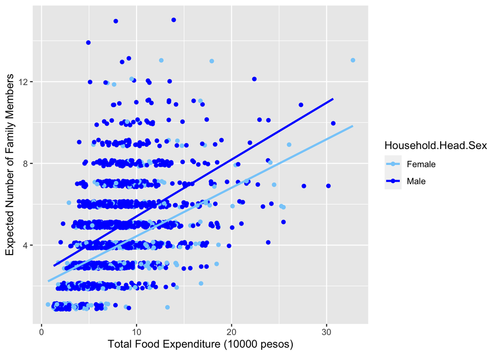

Predicted Numbers of Household Members

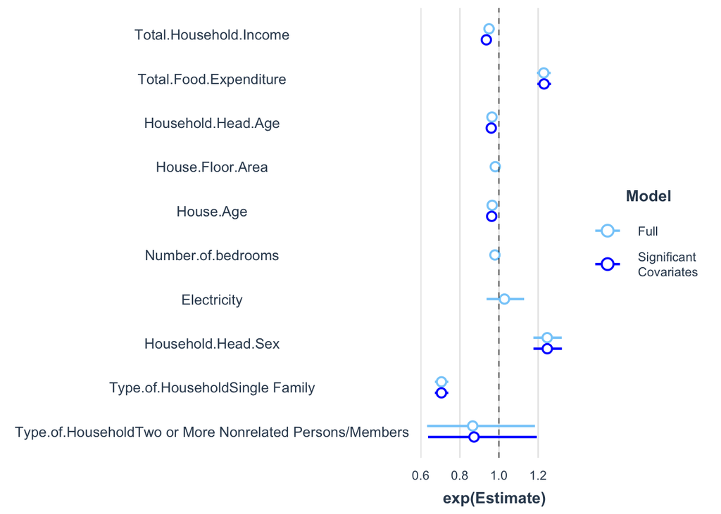

Summary of Coefficients for each fitted Poisson Model

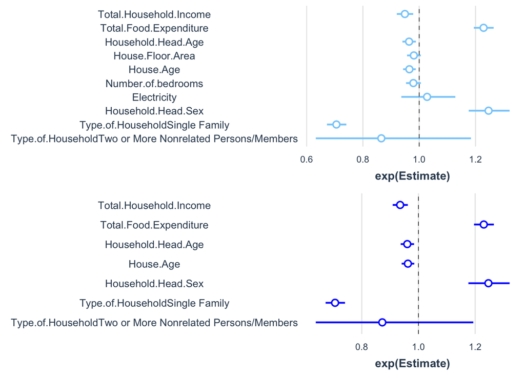

Separate summaries of coefficients for the fitted Poisson Models